# 1. Elección del dataset

Ante la duda de la mejor toma de decisiones durante la fase de preprocesamiento, se han creado varios conjuntos conforme a las 2 variantes ya explicadas.

1. Número de nulos consecutivos máximos aceptados (*gaps*).
2. Particiones de la serie sobre las que se extraen algunas características.
   - Ver en `feature_extraction.py`, `extract_consumption_features`: coeficiente de variación, tendencia, etc.

Con el fin de determinar el conjunto óptimo para las siguientes etapas, se evalúa cada conjunto únicamente sobre el *set* de entrenamiento mediante validación cruzada estratificada (5 *folds*). Para una toma de decisiones más robusta, se evalúa con los 3 modelos de las fases posteriores (*LightGBM*, *XGBoost* y *CatBoost*) con unos parámetros equilibrados que prevengan el *underfitting* u *overfitting* (*learning rate* estable de 0.05, al menos 20 muestras por hoja final, *bagging* en cada iteración, etc.). Las métricas son independientes del umbral de decisión: ROC-AUC y PR-AUC.

Se busca maximizar tanto el rendimiento predictivo como la funcionalidad operativa. Para ello, se pondera el coste en métricas frente a dos criterios prácticos:

- La preferencia por un número de particiones bajo o intermedio, que favorece la eficiencia computacional y la consistencia en clientes con historiales más cortos.
- La capacidad de capturar a los clientes más inestables —con un *max gap* de 670 días, preferible al umbral de 250— para incluir un porcentaje mayor de la BBDD del cliente.

```python
from modeling import evaluate_datasets_baseline
selecting_df_results = evaluate_datasets_baseline()
```

```
Evaluating dataset: gap250_windows12...
Evaluating dataset: gap250_windows2...
Evaluating dataset: gap250_windows4...
Evaluating dataset: gap250_windows8...
Evaluating dataset: gap670_windows12...
Evaluating dataset: gap670_windows2...
Evaluating dataset: gap670_windows4...
Evaluating dataset: gap670_windows8...
```

```python
selecting_df_results
```

|  | Dataset | Num_Features | LightGBM_PR_AUC | LightGBM_ROC_AUC | XGBoost_PR_AUC | XGBoost_ROC_AUC | CatBoost_PR_AUC | CatBoost_ROC_AUC | Preferred_by | Mean_PR_AUC_All |
| --- | --- | --- | --- | --- | --- | --- | --- | --- | --- | --- |
| 0 | gap250_windows12 | 247 | 0.563718 | 0.865448 | 0.553883 | 0.864003 | 0.530125 | 0.860284 | XGBoost, CatBoost | 0.549242 |
| 1 | gap250_windows2 | 161 | 0.564418 | 0.866923 | 0.550035 | 0.859699 | 0.525595 | 0.859498 | LightGBM | 0.546683 |
| 2 | gap250_windows8 | 214 | 0.556605 | 0.865884 | 0.552603 | 0.864725 | 0.528393 | 0.859293 | - | 0.545867 |
| 3 | gap250_windows4 | 180 | 0.549690 | 0.864511 | 0.542963 | 0.862382 | 0.522083 | 0.860761 | - | 0.538245 |
| 4 | gap670_windows2 | 160 | 0.544294 | 0.864223 | 0.536535 | 0.861750 | 0.513038 | 0.860081 | - | 0.531289 |
| 5 | gap670_windows4 | 180 | 0.540854 | 0.865576 | 0.537317 | 0.863964 | 0.514672 | 0.861722 | - | 0.530948 |
| 6 | gap670_windows8 | 214 | 0.540272 | 0.868016 | 0.540151 | 0.864548 | 0.512351 | 0.861958 | - | 0.530925 |
| 7 | gap670_windows12 | 247 | 0.542364 | 0.868383 | 0.536174 | 0.864099 | 0.507423 | 0.863146 | - | 0.528654 |

El conjunto que más maximiza las métricas es el que tiene más resolución (más ventanas) y los clientes más consistentes (*max gap* 250). Los conjuntos con *gaps* menores son, en todos los casos, los que mejor rendimiento logran, mientras, el número de ventanas no sigue la misma lógica. En general, el compromiso entre rendimiento y utilidad operativa no se ve fuertemente afectado por las variantes.

Siguiendo las preferencias prácticas, **se usará la variante con *max gap* 670**. La diferencia promedio de PR-AUC entre los mejores conjuntos de esta variante (250 y 670) es de 2 centésimas. No obstante, la diferencia operativa es mucho mayor que esta leve ganancia de rendimiento. Concretamente, el *EDA* mostró que el límite de aceptación de 250 elimina al 9.69% de los clientes, pero con un límite de 670, tan solo se pierde el 0.21%. Aún siendo probable que esta diferencia de rendimiento se magnifique con modelos mejor ajustados, la variente con 670 permite una discriminación al menos equiparable.

```python
selecting_df_results[selecting_df_results['Dataset'].str.startswith('gap670')]
```

|  | Dataset | Num_Features | LightGBM_PR_AUC | LightGBM_ROC_AUC | XGBoost_PR_AUC | XGBoost_ROC_AUC | CatBoost_PR_AUC | CatBoost_ROC_AUC | Preferred_by | Mean_PR_AUC_All |
| --- | --- | --- | --- | --- | --- | --- | --- | --- | --- | --- |
| 4 | gap670_windows2 | 160 | 0.544294 | 0.864223 | 0.536535 | 0.861750 | 0.513038 | 0.860081 | - | 0.531289 |
| 5 | gap670_windows4 | 180 | 0.540854 | 0.865576 | 0.537317 | 0.863964 | 0.514672 | 0.861722 | - | 0.530948 |
| 6 | gap670_windows8 | 214 | 0.540272 | 0.868016 | 0.540151 | 0.864548 | 0.512351 | 0.861958 | - | 0.530925 |
| 7 | gap670_windows12 | 247 | 0.542364 | 0.868383 | 0.536174 | 0.864099 | 0.507423 | 0.863146 | - | 0.528654 |

```python
df_final_all_features_path = "data/all_features/gap670_windows4.csv"
```

# 2. *BorutaShap* individual

Tras determinar el conjunto base sobre el que trabajar, se aplica la selección de características (*BorutaShap*) para cada modelo. Este planteamiento resuelve:

1. Mayor desempeño individual: los valores *SHAP* se estiman conforme a la utilidad única de las variables para cada modelo.
2. Diversidad: cuando se evalúe la ganancia de aplicar *stacking* o *soft voting*, además de un funcionamiento distinto, cada modelo puede aportar información distinta a la predicción.

Siguiendo el razonamiento anteriormente aplicado (`feature_enineering.ipynb`), esta ejecución se aplica con modelos configurados a modo exploratorio, es decir, enfocados a la exploración de muestras, *bagging* de características y una profundidad limitada.

```python
from feature_selection import compute_boruta_selection_by_model
compute_boruta_selection_by_model(df_final_all_features_path, model_name='lightgbm', n_trials=50)
```

```
Running BorutaShap | LIGHTGBM | gap670_windows4.csv
```

```
Accepted features for LIGHTGBM: 50
Successfully saved to: data/all_features/boruta_feature_selection\lightgbm_boruta_gap670_windows4.json
```

```python
compute_boruta_selection_by_model(df_final_all_features_path, model_name='xgboost', n_trials=50)
```

```
Running BorutaShap | XGBOOST | gap670_windows4.csv
```

```
Accepted features for XGBOOST: 49
Successfully saved to: data/all_features/boruta_feature_selection\xgboost_boruta_gap670_windows4.json
```

```python
compute_boruta_selection_by_model(df_final_all_features_path, model_name='catboost', n_trials=50)
```

```
Running BorutaShap | CATBOOST | gap670_windows4.csv
```

```
Accepted features for CATBOOST: 55
Successfully saved to: data/all_features/boruta_feature_selection\catboost_boruta_gap670_windows4.json
```

```python
import pandas as pd
from feature_selection import apply_boruta_filtering

# Carga de los conjuntos filtrados
df_all_features = pd.read_csv(df_final_all_features_path)

lgbm_selected_features_path = 'data\\all_features\\boruta_feature_selection\\lightgbm_boruta_gap670_windows4.json'
df_lightgbm = apply_boruta_filtering(df_all_features, lgbm_selected_features_path)

xgb_selected_features_path = 'data\\all_features\\boruta_feature_selection\\xgboost_boruta_gap670_windows4.json'
df_xgboost = apply_boruta_filtering(df_all_features, xgb_selected_features_path)

catb_selected_features_path = 'data\\all_features\\boruta_feature_selection\\catboost_boruta_gap670_windows4.json'
df_catboost = apply_boruta_filtering(df_all_features, catb_selected_features_path)
df_catboost.head(2)
```

|  | nulls_mean_consecutive | nulls_step_change_mean | 0_Mean diff | 0_MFCC_0 | cons_global_rolling_var_30d | cons_global_sudden_spikes_count | summer_slope | w4_mean_crossings | nulls_abs_step_change_mean | zeros_center_of_mass | ... | 0_Spectrogram mean coefficient_0.08Hz | sum_win_max_ratio | nulls_entropy | 0_Spectral kurtosis | zero_trans_ratio | summer_std | 0_ECDF Percentile Count_0 | w4_peak_ratio | cons_global_dominant_freq | FLAG |
| --- | --- | --- | --- | --- | --- | --- | --- | --- | --- | --- | --- | --- | --- | --- | --- | --- | --- | --- | --- | --- | --- |
| 0 | 1.333333 | 0.056667 | 0.000242 | -12.264638 | 7.342442 | 15 | -0.899916 | 0.120155 | 0.056667 | 0.497581 | ... | 2.566149 | 0.788955 | 1.039721 | 3.313714 | 0.039652 | 2.438622 | 206.0 | 49000.000000 | 935.905737 | 1 |
| 1 | 20.888889 | 3.595556 | 0.013688 | -9.795095 | 43.235066 | 4 | 7.886767 | 0.139535 | 3.700000 | 0.023694 | ... | 7.243737 | 6.304093 | 1.067929 | 4.393602 | 0.000967 | 8.818545 | 206.0 | 1.646573 | 2927.081090 | 1 |

2 rows × 56 columns

# 3. Estrategias *resampling*

Una vez se ha reducido el espacio de características, en esta fase se comprueba si las estrategias de remuestreo pueden ser útiles previo al modelaje. Gracias a seguir este orden, se facilita la tarea a estos métodos.

Tal y como mostró el *EDA* e *Isolation Forest*, la discriminación de fraude eléctrico tiene la frontera de decisión altamente difusa. Los perfiles infractores tienden a mimetizarse con los patrones de consumo de los clientes honestos. Por ello, las técnicas de remuestreo aleatorio (*Random Oversampling*/*Undersampling*) resultan insuficientes para el caso. Se proponen otros métodos en función de la estrategia.

**Algoritmos de frontera y clustering***  
Los algoritmos *ADASYN y *Borderline-SMOTE* concentran la generación de datos sintéticos exclusivamente en las observaciones minoritarias que son difíciles de clasificar (cercanas a la frontera). Asimismo, se evalúa *K-Means SMOTE*, que agrupa los datos previamente para evitar generar ejemplos sintéticos en zonas dominadas por patrones legítimos.

**Remuestreo híbrido y submuestreo**  
Generar muestras artificiales en zonas de alto solapamiento aumenta el riesgo de introducir ruido y hundir la precisión. Para mitigarlo, se evalúan métodos híbridos (*SMOTEENN* y *SMOTETomek*). Estos, primero sobremuestrean el fraude, después, aplican técnicas de limpieza basadas en vecindad para eliminar las observaciones de la clase mayoritaria que invaden o confunden ese nuevo espacio. Comparativamente, se testea el método de *undersampling NearMiss (v3)*, que busca retener únicamente los clientes legítimos que perfilan la frontera de decisión, descartando los más alejados.

**Pesos nativos (Class Weights)**  
Finalmente, como línea base y alternativa más eficiente, se evalúa el balanceo nativo interno de cada algoritmo (*scale_pos_weight*). Este enfoque no altera la distribución de los datos originales, sino que penaliza de forma asimétrica los errores cometidos sobre la clase minoritaria durante la construcción de los árboles.

```python
from modeling import evaluate_resampling_by_model

results_resampling_lgbm = evaluate_resampling_by_model(df_lightgbm, model_name='lightgbm')
print()
results_resampling_xgb = evaluate_resampling_by_model(df_xgboost, model_name='xgboost')
print()
results_resampling_catboost = evaluate_resampling_by_model(df_catboost, model_name='catboost')
```

```
Evaluating resampling strategies | LIGHTGBM
    Baseline_No_Resampling...
    Class_Weights_Native...
    Oversampling_SMOTE...
    Oversampling_ADASYN...
    Oversampling_Borderline1...
    Oversampling_KMeansSMOTE...
    Undersampling_NearMissV3...
    Hybrid_SMOTETomek...
    Hybrid_SMOTEENN...

Evaluating resampling strategies | XGBOOST
    Baseline_No_Resampling...
    Class_Weights_Native...
    Oversampling_SMOTE...
    Oversampling_ADASYN...
    Oversampling_Borderline1...
    Oversampling_KMeansSMOTE...
    Undersampling_NearMissV3...
    Hybrid_SMOTETomek...
    Hybrid_SMOTEENN...

Evaluating resampling strategies | CATBOOST
    Baseline_No_Resampling...
    Class_Weights_Native...
    Oversampling_SMOTE...
    Oversampling_ADASYN...
    Oversampling_Borderline1...
    Oversampling_KMeansSMOTE...
    Undersampling_NearMissV3...
    Hybrid_SMOTETomek...
    Hybrid_SMOTEENN...
```

```python
display(results_resampling_lgbm)
display(results_resampling_xgb)
display(results_resampling_catboost)
```

|  | Model | Strategy | PR_AUC_mean | ROC_AUC_mean | MCC_mean | Recall_Fraud_mean | Precision_Fraud_mean | F1_Fraud_mean |
| --- | --- | --- | --- | --- | --- | --- | --- | --- |
| 0 | LIGHTGBM | Baseline_No_Resampling | 0.539124 | 0.870331 | 0.443129 | 0.292105 | 0.757798 | 0.421623 |
| 1 | LIGHTGBM | Class_Weights_Native | 0.530603 | 0.867431 | 0.430692 | 0.633828 | 0.383560 | 0.477807 |
| 2 | LIGHTGBM | Oversampling_Borderline1 | 0.485267 | 0.856070 | 0.427279 | 0.443848 | 0.506940 | 0.472866 |
| 3 | LIGHTGBM | Hybrid_SMOTETomek | 0.481374 | 0.853842 | 0.424736 | 0.467045 | 0.481828 | 0.474232 |
| 4 | LIGHTGBM | Oversampling_SMOTE | 0.478642 | 0.853836 | 0.423502 | 0.444667 | 0.499387 | 0.470160 |
| 5 | LIGHTGBM | Oversampling_KMeansSMOTE | 0.476899 | 0.859696 | 0.415778 | 0.386075 | 0.544412 | 0.451637 |
| 6 | LIGHTGBM | Oversampling_ADASYN | 0.475391 | 0.851700 | 0.424389 | 0.451173 | 0.495193 | 0.471785 |
| 7 | LIGHTGBM | Hybrid_SMOTEENN | 0.418862 | 0.840394 | 0.383388 | 0.510978 | 0.388072 | 0.440583 |
| 8 | LIGHTGBM | Undersampling_NearMissV3 | 0.171251 | 0.728355 | 0.219734 | 0.770125 | 0.160562 | 0.265718 |

|  | Model | Strategy | PR_AUC_mean | ROC_AUC_mean | MCC_mean | Recall_Fraud_mean | Precision_Fraud_mean | F1_Fraud_mean |
| --- | --- | --- | --- | --- | --- | --- | --- | --- |
| 0 | XGBOOST | Class_Weights_Native | 0.540066 | 0.866954 | 0.429240 | 0.621220 | 0.388037 | 0.477649 |
| 1 | XGBOOST | Baseline_No_Resampling | 0.539992 | 0.868988 | 0.452852 | 0.297802 | 0.772408 | 0.429828 |
| 2 | XGBOOST | Oversampling_Borderline1 | 0.502005 | 0.854976 | 0.427602 | 0.486166 | 0.471215 | 0.478354 |
| 3 | XGBOOST | Oversampling_KMeansSMOTE | 0.498685 | 0.864706 | 0.431492 | 0.303091 | 0.704176 | 0.423484 |
| 4 | XGBOOST | Oversampling_SMOTE | 0.495901 | 0.852394 | 0.422794 | 0.488195 | 0.461805 | 0.474487 |
| 5 | XGBOOST | Hybrid_SMOTETomek | 0.494674 | 0.851114 | 0.421057 | 0.489824 | 0.457755 | 0.473144 |
| 6 | XGBOOST | Oversampling_ADASYN | 0.484538 | 0.849727 | 0.417212 | 0.491455 | 0.450589 | 0.469953 |
| 7 | XGBOOST | Hybrid_SMOTEENN | 0.480172 | 0.849030 | 0.387226 | 0.617160 | 0.338853 | 0.437469 |
| 8 | XGBOOST | Undersampling_NearMissV3 | 0.143814 | 0.674338 | 0.154324 | 0.753861 | 0.130850 | 0.222980 |

|  | Model | Strategy | PR_AUC_mean | ROC_AUC_mean | MCC_mean | Recall_Fraud_mean | Precision_Fraud_mean | F1_Fraud_mean |
| --- | --- | --- | --- | --- | --- | --- | --- | --- |
| 0 | CATBOOST | Baseline_No_Resampling | 0.525880 | 0.865639 | 0.410358 | 0.243286 | 0.779961 | 0.370732 |
| 1 | CATBOOST | Class_Weights_Native | 0.508931 | 0.862495 | 0.388412 | 0.706257 | 0.305505 | 0.426483 |
| 2 | CATBOOST | Oversampling_Borderline1 | 0.469332 | 0.842215 | 0.399514 | 0.476809 | 0.433608 | 0.454072 |
| 3 | CATBOOST | Oversampling_KMeansSMOTE | 0.465601 | 0.859842 | 0.383398 | 0.244917 | 0.695890 | 0.361831 |
| 4 | CATBOOST | Hybrid_SMOTETomek | 0.462931 | 0.840441 | 0.404531 | 0.490633 | 0.431768 | 0.459024 |
| 5 | CATBOOST | Oversampling_SMOTE | 0.459432 | 0.839350 | 0.400528 | 0.480051 | 0.433545 | 0.454861 |
| 6 | CATBOOST | Hybrid_SMOTEENN | 0.457495 | 0.841986 | 0.370483 | 0.630177 | 0.314735 | 0.419671 |
| 7 | CATBOOST | Oversampling_ADASYN | 0.453027 | 0.837076 | 0.391921 | 0.477621 | 0.421596 | 0.447572 |
| 8 | CATBOOST | Undersampling_NearMissV3 | 0.114121 | 0.607064 | 0.108964 | 0.760788 | 0.113394 | 0.197358 |

Las estrategias de no aplicar *resampling* (*Baseline*) y el uso de pesos (*class weights*) dominan las métricas en todos los modelos. Ambas estrategias mantienen un *PR-AUC* y *ROC-AUC* superiores y prácticamente idénticos entre sí. La diferencia radica en su comportamiento predictivo ante el umbral estándar (0.5): el *Baseline* tiende a ignorar la clase minoritaria (maximiza precisión a costa de *recall*) y los pesos de clase mejoran drásticamente la tasa de detección.

En consecuencia, se descarta el uso de todas las técnicas de remuestreo. El tratamiento del desbalance se abordará exclusivamente mediante el balance de pesos nativo de los algoritmos.

# 4. Optimización de hiperparámetros

Se utiliza la librería `Optuna` para optimizar automáticamente los hiperparámetros de los modelos. *Optuna* explora distintas combinaciones de parámetros mediante un proceso iterativo (*trials*), guiado por un algoritmo eficiente que prioriza las configuraciones más prometedoras.

En cada *trial* se evalúa el modelo mediante validación cruzada estratificada, optimizando la métrica *PR-AUC*. Además, se aplica *early stopping* para detener el crecimiento de árboles, y *pruning*, que detiene entrenamientos poco prometedores de forma anticipada (segundo *fold*), reduciendo el tiempo de cómputo y centrando la búsqueda en las mejores soluciones.

```python
from modeling import optimize_model_optuna

study_lgbm = optimize_model_optuna(df_lightgbm, model_name='lightgbm', n_trials=150)
```

```
Optuna Optimization for: LIGHTGBM
Target Metric: PR-AUC | Trials: 150
```

```
== BEST RESULTS FOR LIGHTGBM ==
Best PR-AUC: 0.5543
Best Hyperparameters:
  learning_rate=0.015059129695541297
  max_depth=10
  num_leaves=135
  min_child_samples=23
  extra_trees=False
  path_smooth=7.800746949513345
  min_split_gain=0.48620240594309666
  max_bin=512
  subsample=0.8789922623725623
  subsample_freq=1
  colsample_bytree=0.5355052504230148
  reg_alpha=0.07734158964076825
  reg_lambda=1.8384492653520905
  scale_pos_weight=8.434159430655027
```

```python
study_xgboost = optimize_model_optuna(df_xgboost, model_name='xgboost', n_trials=150)
```

```
Optuna Optimization for: XGBOOST
Target Metric: PR-AUC | Trials: 150
```

```
== BEST RESULTS FOR XGBOOST ==
Best PR-AUC: 0.5623
Best Hyperparameters:
  learning_rate=0.031281154924018006
  max_depth=8
  min_child_weight=1
  max_bin=512
  subsample=0.80460540960462
  colsample_bytree=0.4351765919591846
  colsample_bylevel=0.7658589496534407
  colsample_bynode=0.7979820383549903
  gamma=0.15084183242896854
  reg_alpha=0.021010223260093705
  reg_lambda=0.033487579190729276
  scale_pos_weight=3.0148111781165463
```

```python
study_catboost = optimize_model_optuna(df_catboost, model_name='catboost', n_trials=150)
```

```
Optuna Optimization for: CATBOOST
Target Metric: PR-AUC | Trials: 150
```

```
== BEST RESULTS FOR CATBOOST ==
Best PR-AUC: 0.5558
Best Hyperparameters:
  learning_rate=0.02651206887347492
  depth=7
  l2_leaf_reg=3.0938740979168218
  random_strength=0.17681214646097154
  rsm=0.9669779113815028
  bootstrap_type=Bernoulli
  leaf_estimation_iterations=1
  border_count=128
  scale_pos_weight=1.230055093835792
  subsample=0.8700245074809156
```

```python
from modeling import save_optuna_params
optuna_path = 'data/optuna_parameters'
save_optuna_params(study_lgbm, 'lightgbm', save_dir=optuna_path)
save_optuna_params(study_xgboost, 'xgboost', save_dir=optuna_path)
save_optuna_params(study_catboost, 'catboost', save_dir=optuna_path)
```

```
Saved LIGHTGBM parameters to: data/optuna_parameters\lightgbm_params.json
Saved XGBOOST parameters to: data/optuna_parameters\xgboost_params.json
Saved CATBOOST parameters to: data/optuna_parameters\catboost_params.json
```

Carga en una nueva sesión.

```python
from modeling import load_optuna_params
from lightgbm import LGBMClassifier
from xgboost import XGBClassifier
from catboost import CatBoostClassifier

optuna_path = 'data/optuna_parameters'
lgbm_params = load_optuna_params(model_name='lightgbm', load_dir=optuna_path)
xgboost_params = load_optuna_params(model_name='xgboost', load_dir=optuna_path)
catboost_params = load_optuna_params(model_name='catboost', load_dir=optuna_path)

lgbm_model = LGBMClassifier(**lgbm_params)
xgb_model = XGBClassifier(**xgboost_params)
cat_model = CatBoostClassifier(**catboost_params)
```

# 5. Evaluación individual

```python
from utils import stratified_train_val_test_split
from modeling import evaluate_best_model

train_lgbm, val_lgbm, test_lgbm = stratified_train_val_test_split(df_lightgbm)
model_lgbm, val_probs_lgbm, test_probs_lgbm, th_lgbm, lgbm_results, lgbm_summary = evaluate_best_model(
    lgbm_model, 'LightGBM', train_lgbm, val_lgbm, test_lgbm
)

train_xgb, val_xgb, test_xgb = stratified_train_val_test_split(df_xgboost)
model_xgb, val_probs_xgb, test_probs_xgb, th_xgb, xgb_results, xgb_summary = evaluate_best_model(
    xgb_model, 'XGBoost', train_xgb, val_xgb, test_xgb
)

train_cat, val_cat, test_cat = stratified_train_val_test_split(df_catboost)
model_cat, val_probs_cat, test_probs_cat, th_cat, cat_results, cat_summary = evaluate_best_model(
    cat_model, 'CatBoost', train_cat, val_cat, test_cat
)
```

```
============================================================
Evaluating: LIGHTGBM

Results for seed: 42
-> Trees Created (Best Iteration): 2348
-> Best Threshold (Precision>=0.55 & Max MCC): 0.3565 | Val. Prec: 0.5912, MCC: 0.4961

TEST METRICS
    ROC-AUC: 0.8685
    PR-AUC:  0.5430
    MCC:     0.4649
------------------------------------------------------------
Average training time: 13.16 sec
============================================================

============================================================
Evaluating: XGBOOST

Results for seed: 42
-> Trees Created (Best Iteration): 1275
-> Best Threshold (Precision>=0.55 & Max MCC): 0.2377 | Val. Prec: 0.6225, MCC: 0.4738

TEST METRICS
    ROC-AUC: 0.8657
    PR-AUC:  0.5415
    MCC:     0.4632
------------------------------------------------------------
Average training time: 13.92 sec
============================================================

============================================================
Evaluating: CATBOOST

Results for seed: 42
-> Trees Created (Best Iteration): 2520
-> Best Threshold (Precision>=0.55 & Max MCC): 0.3466 | Val. Prec: 0.6418, MCC: 0.4760

TEST METRICS
    ROC-AUC: 0.8680
    PR-AUC:  0.5494
    MCC:     0.4799
------------------------------------------------------------
Average training time: 27.63 sec
============================================================
```

```python
display(lgbm_results)
display(lgbm_summary)
```

|  | Seed | Threshold | PR-AUC | ROC-AUC | MCC | F1_Macro | Recall_Fraud | Recall_NoFraud | Precision_Fraud | Precision_NoFraud |
| --- | --- | --- | --- | --- | --- | --- | --- | --- | --- | --- |
| 0 | 42 | 0.356465 | 0.542994 | 0.868464 | 0.464883 | 0.731742 | 0.476281 | 0.961559 | 0.543290 | 0.950306 |
| 1 | 123 | 0.366364 | 0.539983 | 0.863462 | 0.445646 | 0.722121 | 0.459203 | 0.960102 | 0.524946 | 0.948695 |
| 2 | 456 | 0.336667 | 0.534390 | 0.865684 | 0.440313 | 0.720109 | 0.480076 | 0.953361 | 0.497053 | 0.950245 |
| 3 | 789 | 0.376263 | 0.536130 | 0.863916 | 0.452922 | 0.725275 | 0.455408 | 0.963017 | 0.541761 | 0.948502 |
| 4 | 1011 | 0.415859 | 0.543091 | 0.867732 | 0.450499 | 0.722171 | 0.426945 | 0.968665 | 0.566751 | 0.946254 |

|  | Mean_Std |
| --- | --- |
| Threshold | 0.370 ± 0.029 |
| PR-AUC | 0.539 ± 0.004 |
| ROC-AUC | 0.866 ± 0.002 |
| MCC | 0.451 ± 0.009 |
| F1_Macro | 0.724 ± 0.005 |
| Recall_Fraud | 0.460 ± 0.021 |
| Recall_NoFraud | 0.961 ± 0.006 |
| Precision_Fraud | 0.535 ± 0.026 |
| Precision_NoFraud | 0.949 ± 0.002 |

```python
display(xgb_results)
display(xgb_summary)
```

|  | Seed | Threshold | PR-AUC | ROC-AUC | MCC | F1_Macro | Recall_Fraud | Recall_NoFraud | Precision_Fraud | Precision_NoFraud |
| --- | --- | --- | --- | --- | --- | --- | --- | --- | --- | --- |
| 0 | 42 | 0.237677 | 0.541508 | 0.865689 | 0.463177 | 0.726828 | 0.421252 | 0.972855 | 0.598383 | 0.945970 |
| 1 | 123 | 0.217879 | 0.545739 | 0.866068 | 0.467926 | 0.732342 | 0.461101 | 0.965750 | 0.563805 | 0.949150 |
| 2 | 456 | 0.178283 | 0.538845 | 0.861646 | 0.464171 | 0.731165 | 0.470588 | 0.962653 | 0.547461 | 0.949847 |
| 3 | 789 | 0.148586 | 0.553799 | 0.868255 | 0.462614 | 0.731194 | 0.495256 | 0.956458 | 0.522000 | 0.951777 |
| 4 | 1011 | 0.306970 | 0.545863 | 0.864425 | 0.460349 | 0.720334 | 0.383302 | 0.979413 | 0.641270 | 0.942992 |

|  | Mean_Std |
| --- | --- |
| Threshold | 0.218 ± 0.061 |
| PR-AUC | 0.545 ± 0.006 |
| ROC-AUC | 0.865 ± 0.002 |
| MCC | 0.464 ± 0.003 |
| F1_Macro | 0.728 ± 0.005 |
| Recall_Fraud | 0.446 ± 0.044 |
| Recall_NoFraud | 0.967 ± 0.009 |
| Precision_Fraud | 0.575 ± 0.046 |
| Precision_NoFraud | 0.948 ± 0.003 |

```python
display(cat_results)
display(cat_summary)
```

|  | Seed | Threshold | PR-AUC | ROC-AUC | MCC | F1_Macro | Recall_Fraud | Recall_NoFraud | Precision_Fraud | Precision_NoFraud |
| --- | --- | --- | --- | --- | --- | --- | --- | --- | --- | --- |
| 0 | 42 | 0.346566 | 0.549448 | 0.867971 | 0.479913 | 0.732939 | 0.417457 | 0.977227 | 0.637681 | 0.945865 |
| 1 | 123 | 0.267374 | 0.542527 | 0.867159 | 0.461897 | 0.730420 | 0.478178 | 0.960284 | 0.536170 | 0.950415 |
| 2 | 456 | 0.247576 | 0.551182 | 0.870485 | 0.459863 | 0.729762 | 0.489564 | 0.957005 | 0.522267 | 0.951286 |
| 3 | 789 | 0.297071 | 0.542004 | 0.866600 | 0.456417 | 0.726107 | 0.444023 | 0.966478 | 0.559809 | 0.947660 |
| 4 | 1011 | 0.267374 | 0.547072 | 0.869189 | 0.451920 | 0.725339 | 0.466793 | 0.960102 | 0.529032 | 0.949378 |

|  | Mean_Std |
| --- | --- |
| Threshold | 0.285 ± 0.039 |
| PR-AUC | 0.546 ± 0.004 |
| ROC-AUC | 0.868 ± 0.002 |
| MCC | 0.462 ± 0.011 |
| F1_Macro | 0.729 ± 0.003 |
| Recall_Fraud | 0.459 ± 0.029 |
| Recall_NoFraud | 0.964 ± 0.008 |
| Precision_Fraud | 0.557 ± 0.047 |
| Precision_NoFraud | 0.949 ± 0.002 |

Los tres modelos obtienen un rendimiento global consistente tras evaluar múltiples semillas, con valores medios de *ROC-AUC* y *PR-AUC* muy similares, aunque ligeramente inferiores en *LightGBM*. Entre las alternativas, *CatBoost* superar por 1 o 2 milésimas a *XGBoost* en las métricas de separabilidad media, con un *PR-AUC* de 0.546 y *ROC-AUC* de 0.868. Similarmente, *XGBoost* logra, por poco, el mejor *MCC* (0.464 frente a 0.462). Sin embargo, la elección del modelo final debe fundamentarse en el umbral operativo y alinearse con los requerimientos del negocio a través del equilibrio de errores más deseado.

Para profundizar, se grafica la curva de *precision-recall*.

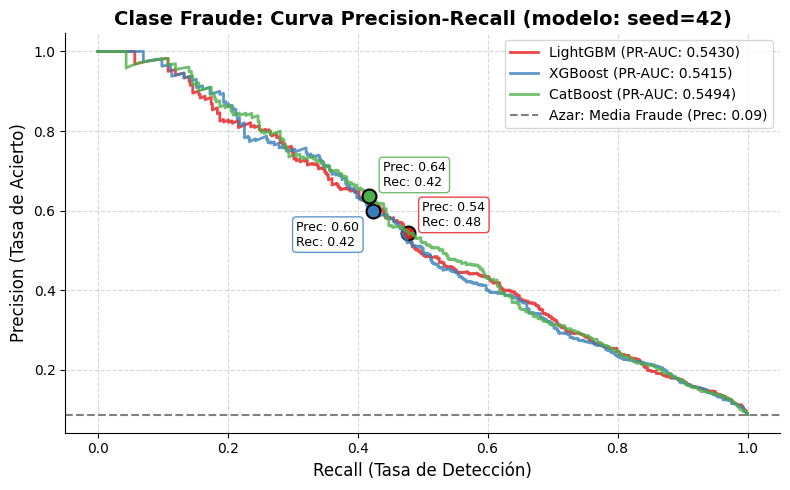

```python
import matplotlib.pyplot as plt
from sklearn.metrics import precision_recall_curve, average_precision_score
import seaborn as sns
import numpy as np

def plot_pr_curve_with_operating_points(y_test, probs_dict, thresholds_dict):
    plt.figure(figsize=(8, 5))
    palette = sns.color_palette("Set1", len(probs_dict))
    colors = {'LightGBM': palette[0],'XGBoost': palette[1], 'CatBoost': palette[2], }
    label_offsets = {'LightGBM': (10, 5), 'XGBoost': (-55, -25), 'CatBoost': (10, 7)}

    for name, probs in probs_dict.items():
        precision, recall, pr_thresholds = precision_recall_curve(y_test, probs)
        # Líneas de la curva
        plt.plot(recall, precision, label=f'{name} (PR-AUC: {average_precision_score(y_test, probs):.4f})',
                 color=colors[name], linewidth=2, alpha=0.8)
        # Umbral óptimo
        chosen_th = thresholds_dict[name]
        idx = np.argmin(np.abs(pr_thresholds - chosen_th))
        # Marker umbral
        plt.plot(recall[idx], precision[idx], marker='o', markersize=10,
                 markeredgecolor='black', markeredgewidth=1.5, color=colors[name])
        # Valores por modelo
        plt.annotate(f"Prec: {precision[idx]:.2f}\nRec: {recall[idx]:.2f}",
                     (recall[idx], precision[idx]), textcoords="offset points",
                     xytext=label_offsets[name], ha='left', fontsize=9,
                     bbox=dict(boxstyle="round,pad=0.3", fc="white", ec=colors[name], alpha=0.8))

    plt.title('Clase Fraude: Curva Precision-Recall (modelo: seed=42)', fontsize=14, fontweight='semibold')
    plt.xlabel('Recall (Tasa de Detección)', fontsize=12)
    plt.ylabel('Precision (Tasa de Acierto)', fontsize=12)

    # Línea base aleatoria
    baseline = y_test.mean()
    plt.axhline(baseline, color='gray', linestyle='--', label=f'Azar: Media Fraude (Prec: {baseline:.2f})')

    plt.legend(loc='best')
    plt.grid(True, linestyle='--', alpha=0.5)
    sns.despine()
    plt.tight_layout()
    plt.show()

probs_dict = {'LightGBM': test_probs_lgbm, 'XGBoost': test_probs_xgb, 'CatBoost': test_probs_cat}
thresholds_dict = {'LightGBM': th_lgbm, 'XGBoost': th_xgb, 'CatBoost': th_cat}
plot_pr_curve_with_operating_points(test_xgb['FLAG'], probs_dict, thresholds_dict)
```

Notando que la diferencia coste-ganancia entre todos los modelos es prácticamente nula. En este gráfico concreto, la curva *precision-recall* quizás más interesante a nivel operativo se disputa entre *CatBoost* (verde) y *XGBoost* (azul). Puesto que logran un aumento, aunque insignificante, en la tasa de acierto del segundo cuadrante (superior izquierdo), que es la zona con mayor porcentaje de inspecciones exitosas.

En cualquier caso y pese a ser modelos muy similares, ***XGboost* se determina como el mejor modelo individual** dada la consistencia de sus métricas y la conveniencia operativa.

# 6. *Soft voting* y *stacking*

El *soft voting* propuesto combina los modelos promediando sus probabilidades, mientras que el *stacking* entrena un modelo adicional (en este caso, regresión logística) para aprender cómo combinar sus predicciones. Aunque estas técnicas pueden mejorar el rendimiento, también reducen la explicabilidad del modelo final, lo que puede ser relevante desde el punto de vista operativo, legal y ético. Por ello, solo se consideran si aportan una mejora clara frente a los anteriores.

```python
from modeling import evaluate_ensembles

val_probs_dict = {
    'LightGBM': val_probs_lgbm,
    'XGBoost': val_probs_xgb,
    'CatBoost': val_probs_cat
}

test_probs_dict = {
    'LightGBM': test_probs_lgbm,
    'XGBoost': test_probs_xgb,
    'CatBoost': test_probs_cat
}

# Cualquier val o test
evaluate_ensembles(val_probs_dict, test_probs_dict, val_lgbm['FLAG'], test_lgbm['FLAG'])
```

```
============================================================
 EVALUATING ENSEMBLES (SOFT VOTING & STACKING)
============================================================

	** SOFT VOTING (Average) **
-> Best Threshold (Val): 0.2476 (Prec: 0.5711, MCC: 0.4944)
    TEST ROC-AUC: 0.8717
    TEST PR-AUC:  0.5557
    TEST MCC:     0.4620

Classification Report (Soft Voting):
              precision    recall  f1-score   support

           0     0.9512    0.9581    0.9546      5489
           1     0.5277    0.4877    0.5069       527

    accuracy                         0.9169      6016
   macro avg     0.7394    0.7229    0.7308      6016
weighted avg     0.9141    0.9169    0.9154      6016

------------------------------------------------------------

	** STACKING (Logistic Regression) **
Logistic Regression Coefficients:
  - LightGBM: 3.2969
  - XGBoost: 0.1475
  - CatBoost: 3.1206

 Best Threshold (Val): 0.1783 (Prec: 0.5696, MCC: 0.4986)
    TEST ROC-AUC: 0.8714
    TEST PR-AUC:  0.5543
    TEST MCC:     0.4642

Classification Report (Stacking):
              precision    recall  f1-score   support

           0     0.9526    0.9546    0.9536      5489
           1     0.5165    0.5047    0.5106       527

    accuracy                         0.9152      6016
   macro avg     0.7345    0.7297    0.7321      6016
weighted avg     0.9144    0.9152    0.9148      6016
```

En cuanto a los resultados, tanto el *soft voting* como el *stacking* logran un incremento marginal en las métricas globales de probabilidad (*ROC-AUC* de 0.87 y *PR-AUC* de 0.55) sobre el mejor modelo base. En términos de decisión operativa, ninguno aporta una mejora práctica frente a *XGBoost*, dado que las métricas de *MCC* en test se mantienen exactas o decrecen levemente.

Analizando el comportamiento por clases, ambas técnicas tienden a equilibrar la precisión y el *recall* (rondando el 50%-50%). Esto supone una pérdida directa de la mayor precisión (57.5%) que consolidaba a *XGBoost* como la opción más eficiente, lo que en la práctica se traduciría en un aumento indeseado de inspecciones fallidas (*FP*).

Por otro lado, la regresión logística del *stacking* asigna los pesos mayoritarios a *LightGBM* (3.3) y *CatBoost* (3.1), relegando curiosamente a *XGBoost* a una contribución prácticamente nula (0.15).

En suma, puesto que ninguna de las técnicas logra superar el rendimiento del mejor modelo individual y su implementación implica una pérdida de interpretabilidad directa, no se justifica el uso de ensamblados. Por consiguiente, se mantiene a *XGBoost* como el modelo tabular definitivo.

# 7. Explicabilidad

En base a la documentación de [XGBoost](https://xgboosting.com/which-xgboost-feature-importance-to-use/):

- La importancia por ganancia representa la mejora de exactitud que aporta una característica a las ramas en las que se encuentra.
- La importancia por particiones (*splits*) cuenta el número de veces que se utiliza una característica para dividir los datos entre todos los árboles.
- La importancia por cobertura es la media de particiones que usan la característica, y representa el número de muestras (clientes) afectadas por la partición.

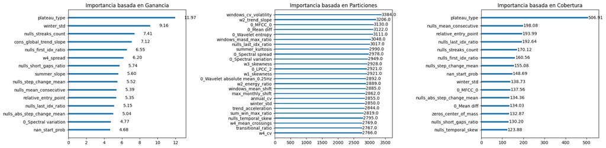

```python
from xgboost import plot_importance

ylabel = None
xlabel = None
fig, (ax1, ax2, ax3) = plt.subplots(1, 3, figsize=(20, 5))
plot_importance(model_xgb, ax=ax1, importance_type='gain',
                ylabel=ylabel, xlabel=xlabel,
                max_num_features=15, values_format='{v:.2f}',
                grid=False, title='Importancia basada en Ganancia')
plot_importance(model_xgb, ax=ax2, importance_type='weight',
                ylabel=ylabel, xlabel=xlabel,
                max_num_features=25, grid=False, title='Importancia basada en Particiones')
plot_importance(model_xgb, ax=ax3, importance_type='cover',
                ylabel=ylabel, xlabel=xlabel,
                max_num_features=15, values_format='{v:.2f}',
                grid=False, title='Importancia basada en Cobertura')
plt.tight_layout()
plt.show()
```

Siendo en este caso el gráfico basado en particiones (central) de menor importancia dada la configuración del modelo. En sus parámetros se establecieron valores de *bagging* forzosos en varios niveles (*colsample_bytree*, *colsample_bylevel*, *colsample_bynode*), por ello, el número de *splits* donde aparece cada característica es artificialmente elevado en muchos casos.

Por otro lado, en las importancias de ganancia y cobertura, destaca mucho la variable categórica *plateau_type* (mide consumos planos), siendo la que mayor reducción de error (*gain*) aporta y la que mayor cantidad de observaciones afecta por partición (*coverage*). Le siguen métricas relacionadas con la dispersión de consumo (*0_spectral_variation*, *winter_std*) y una gran cantidad de variables relacionadas con los nulos: *nulls_abs_step_change_mean* (valores antes y después de nulos), posición de nulos (*idx*), nulos consecutivos, etc.

Ahora, para comprender el impacto real en la predicción final, se emplea la importancia global *SHAP* (*Shapley Additive exPlanations*). Mientras que la ganancia mide la eficiencia de un nodo en el árbol, *SHAP* cuantifica cuánto altera cada variable la probabilidad de salida.

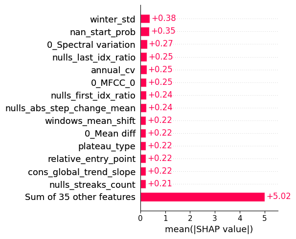

```python
import shap

X_test_xgb = test_xgb.drop(columns=['FLAG'])
y_test_xgb = test_xgb['FLAG']

explainer = shap.TreeExplainer(model_xgb)
# Valores SHAP para test
shap_values = explainer(X_test_xgb)
# Gráfico de importancia global
shap.plots.bar(shap_values, max_display=15, show=False)
plt.gcf().set_size_inches(6, 5)
plt.tight_layout()
plt.show()
```

En este caso, la desviación típica invernal y la probabilidad de transición a un valor nulo (*nan_start_prob*) emergen, por bastante diferencia como las más determinantes. Les siguen varias medidas que registran la variación del consumo, tales como: la variación espectral (*0_Spectral variation*), el coeficiente de variación anual (*annual_cv*), diferencias entre las medias de las particiones (*windows_mean_shift*), la media de las diferencias (*0_Mean diff*) y la ya reconocida *plateau_type*.

Como era de esperar, las variables relacionadas con los valores ausentes presentan un gran peso promedio. Dentro de estas, llama la atención la posición temporal de los nulos (*null_last_idx_ratio* y *null_first_idx_ratio*). Entendiendo que el modelo ha encontrado un patrón, quizás relacionado con medidas aplicadas al sistema de medición.

Curiosamente, la extracción de los Coeficientes Cepstrales en las Frecuencias de Mel (*MFCC*, extracción de características de audio para *ML*) también tiene una importancia intermedia o elevada.

A continuación, se dibuja el gráfico *Beeswarm*, que relaciona el valor de la característica (color) con el impacto predictivo hacia el fraude (valores *SHAP* positivos a la derecha) o hacia la clientela honesta (negativos a la izquierda).

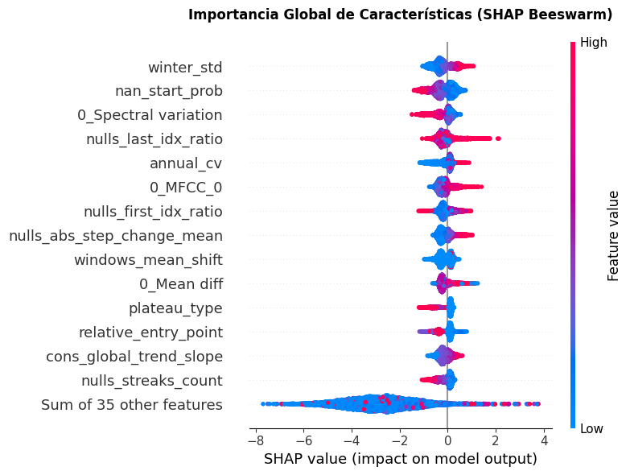

```python
shap.plots.beeswarm(shap_values, max_display=15, show=False)
plt.gcf().set_size_inches(8, 6)
plt.title("Importancia Global de Características (SHAP Beeswarm)", fontweight='semibold', pad=20)
plt.tight_layout()
plt.show()
```

Es muy llamativo el comportamiento de las medidas de variación. *Winter_std* y *annual_cv* altas empujan hacia fraude, mientras que una *spectral_variation* alta —señal más irregular— apunta hacia clientes honestos. En la misma línea, rachas largas de consumo casi idéntico (*plateau_type* alto) se asocian a no fraude. En conjunto, el modelo identifica el fraude como un consumo globalmente volátil en magnitud, pero cuya forma se repite con pocos cambios a lo largo del tiempo (variación espectral), con períodos cortos variables.

Sobre los valores nulos, también es llamativo que las fechas tardías del primer y último nulo empujen hacia ambas direcciones, lo que impide interpretarlas de forma aislada como un simple cambio en el sistema de medición. Por otro lado, la probabilidad de pasar de un registro real a uno nulo (*nan_start_prob*) es menor en fraude, y lo mismo indica *nulls_streaks_count*. En cambio, sí es característico del fraude que la diferencia de consumo antes y después de un valor nulo sea notablemente mayor.

Coincidiendo con el *EDA*, se aprecia como el crecimiento en la tendencia de consumo global también se relaciona con cierta fuerza con el fraude.

Ahora, se propone graficar 2 ejemplos de explicabilidad local. Este tipo de gráficos, además de explicar el modelo, pueden ser una herramienta útil para los operarios que realicen las inspecciones.

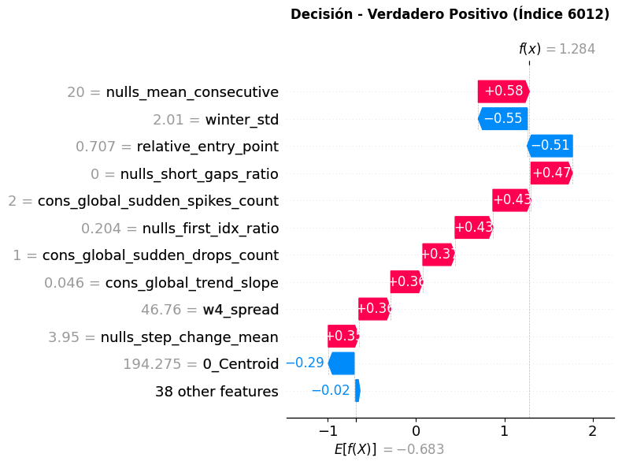

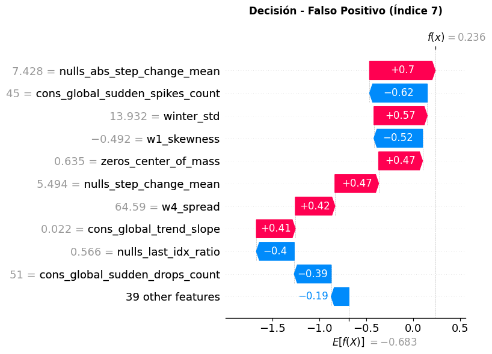

```python
# Explicablidad local con el umbral de XGBoost
test_preds = (test_probs_xgb >= th_xgb).astype(int)
true_positives = np.where((test_preds == 1) & (y_test_xgb == 1))[0]
false_positives = np.where((test_preds == 1) & (y_test_xgb == 0))[0]

# Cambiar para ver otros clientes
idx_tp = true_positives[-1]
idx_fp = false_positives[0]

# Gráfico TP
shap.plots.waterfall(shap_values[idx_tp], max_display=12, show=False)
plt.gcf().set_size_inches(8, 6)
plt.title(f"Decisión - Verdadero Positivo (Índice {idx_tp})", fontweight='bold', pad=20)
plt.tight_layout()
plt.show()

# Y FP
plt.figure(figsize=(6, 4))
shap.plots.waterfall(shap_values[idx_fp], max_display=11, show=False)
plt.gcf().set_size_inches(8, 6)
plt.title(f"Decisión - Falso Positivo (Índice {idx_fp})", fontweight='bold', pad=20)
plt.tight_layout()
plt.show()
```

**Caso TP**  
El modelo detecta varias señales de manipulación. Ninguna racha de nulos es inferior a 7 días (*nulls_short_gaps_ratio*), mientras que la media de días consecutivos nulos es elevada (*nulls_mean_consecutive* = 20); esta combinación incrementa la probabilidad de fraude en +1.05. A ello se suma que el consumo posterior a un valor nulo supera el cuantil 0.75 (+0.35), y que tanto el número de picos como de valles (*cons_global_sudden_spikes_count* y *drops_count*) se sitúan cerca del mínimo del conjunto de clientes. Completan el perfil fraudulento una tendencia de consumo marcadamente alcista (*cons_global_trend_slope*) y un rango mínimo-máximo en el último tramo superior al cuantil 0.9. Todo ello pesa más que los indicios de honestidad: baja varianza invernal (-0.55) y ser un cliente reciente (*relative_entry_point*, -0.51).